# Sensitivity testing: Yield bright spots

Dr. Emily Burchfield

# Set up

```r
library(tidyverse)
library(sp)
library(spdplyr)
library(spdep)
library(INLA)

county <- readRDS("./data/county.RDS")
null <- readRDS("./data/null.RDS")%>% filter(YEAR < 2017)
# census <- readRDS("./data/census.RDS")
# yield <- readRDS("./data/yield.RDS") %>% filter(YEAR %in% unique(census$YEAR)) # built from Survey
# prism <- readRDS("./data/corn_PRISM.RDS")
```

# 1. Model preparation

Null model dataset based on 7626 observations across 4 years.

## 1.1. Spatial structure

The yield data available is at a county scale and the distribution of yields across space exhibits strong autocorrelation where yields in neighboring counties are more alike than yields in distant counties. This spatial autocorrelation is accounted for using a standard Conditional Autoreggressive dependency model based on adjacency for all counties in the conterminous US. In order to account for additional county-specific factors that contribute to yields a county iid random effect term is also included, yielding a Besag-York-Mollie (BYM) spatial dependency model. A county adjacency matrix is created for each crop under investigation.

```r
# rook structure
library(INLA)
library(spdep)
library(spdplyr)

county_sub <- county %>% filter(GEOID %in% unique(null$GEOID)) %>%
  arrange(GEOID)
county_sub$ID <- 1:nrow(county_sub@data)
# relational matrix
temp <- poly2nb(county_sub, queen=F) # rook
h_adj <- nb2mat(temp, style="B", zero.policy = T)
h_adj <- as(h_adj, "dgTMatrix") # sparse style matrix conversion
saveRDS(h_adj, "./data/neighborhood.RDS")
```

The following code visualizes this network:

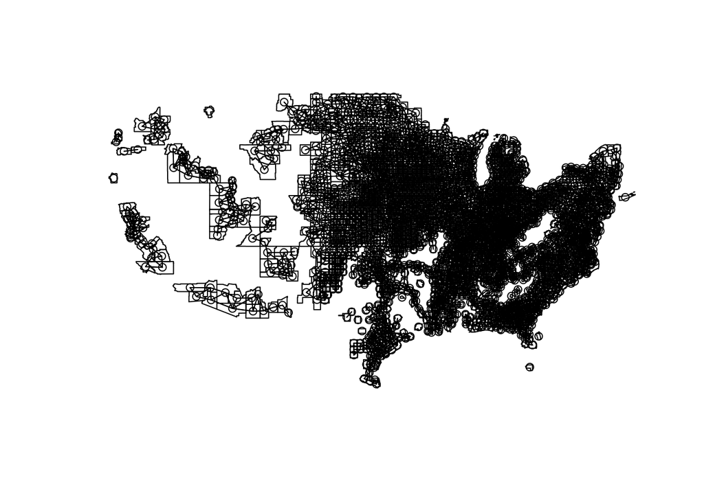

```r
county_sub <- county %>% filter(GEOID %in% unique(null$GEOID)) %>%
  arrange(GEOID)
rook <- poly2nb(county_sub, queen=F)
coords <- coordinates(county_sub)
plot(county_sub)
plot(rook, coords, add=T, main = "Rook")
```

```r
# queen structure
library(INLA)
library(spdep)
library(spdplyr)

county_sub <- county %>% filter(GEOID %in% unique(null$GEOID)) %>%
  arrange(GEOID)
county_sub$ID <- 1:nrow(county_sub@data)
# relational matrix
temp <- poly2nb(county_sub, queen=T)
h_adj <- nb2mat(temp, style="B", zero.policy = T)
h_adj <- as(h_adj, "dgTMatrix") # sparse style matrix conversion
saveRDS(h_adj, "./data/neighborhood_queen.RDS")
```

The following code visualizes this network:

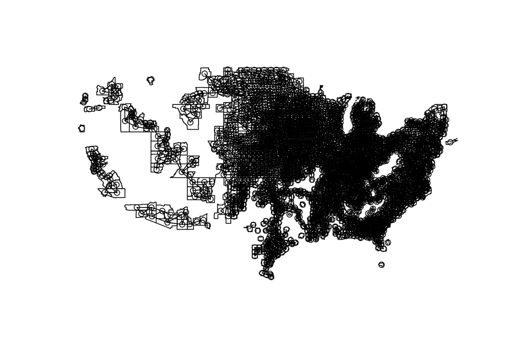

```r
county_sub <- county %>% filter(GEOID %in% unique(null$GEOID)) %>%
  arrange(GEOID)
queen <- poly2nb(county_sub, queen=T)
coords <- coordinates(county_sub)
plot(county_sub)
plot(queen, coords, add=T, main = "Queen")
```

Let’s quickly confirm that spatial autocorrelation is an issue:

```r
# row standardization
rsd_wts <- nb2listw(rook, zero.policy = T) # zero.policy allows inclusion of zero-neighbor entities

county_sub <- county %>% filter(GEOID %in% unique(null$GEOID)) %>%
  arrange(GEOID)
county_sub <- merge(county_sub, null %>% filter(YEAR == 2012), by = "GEOID")
# Moran's I
rsd_moran <- moran.test(county_sub$YIELD, listw = rsd_wts, randomisation = T, na.action = na.omit, zero.policy = T)
rsd_moran
```

```
##
##  Moran I test under randomisation
##
## data:  county_sub$YIELD
## weights: rsd_wts
## omitted: 1, 3, 9, 10, 14, 15, 25, 26, 35, 36, 38, 39, 41, 43, 46, 51, 53, 55, 57, 58, 59, 60, 61, 62, 63, 64, 68, 72, 77, 82, 83, 87, 88, 90, 95, 99, 102, 103, 104, 107, 108, 110, 113, 115, 116, 119, 123, 126, 128, 130, 131, 133, 134, 135, 136, 139, 142, 143, 144, 157, 158, 159, 160, 161, 162, 16…
##
##
## Moran I statistic standard deviate = 45.882, p-value < 2.2e-16
## alternative hypothesis: greater
## sample estimates:
## Moran I statistic       Expectation          Variance
##      0.7725500625     -0.0005991612      0.0002839515
```

Because our p-value is very significant, we can reject the null of randomly distributed data. We have significant spatial autocorrelation in the yield data, which justifies the inclusion of a `bym` model.

## 1.2. Prepare data

```r
library(tidyverse)
library(INLA)
library(spdplyr)

# load adjacency matrix
hadj <- readRDS("./data/neighborhood.RDS")

# add ID
county_sub <- county %>% filter(GEOID %in% unique(null$GEOID)) %>%
  arrange(GEOID) %>%
  mutate(STATE = as.factor(STATEFP)) %>%
  dplyr::select(GEOID, STATE)
county_sub$ID <- 1:nrow(county_sub@data)

null <- merge(null, county_sub@data, by = "GEOID", all = T)

# bin to nearest 10 (-2 does 100), resolution at which estimation occurs
null$TP<-round(null$TP,-1)
null$GDD<-round(null$GDD,-1)
null$SDD<-round(null$SDD,-1)

# set up priors (used in rw1 functions)
u=sd(null$YIELD,na.rm=TRUE)
```

## 1.3. Functions

```r
run_model <- function(formula, data, name, save=T) {
  out <- inla(formula, data=data, family="gaussian",
              control.predictor = list(compute=T),
              control.compute = list(dic=T, cpo=T))
  if (save==T) {
    saveRDS(out, paste0("./out/", name, ".RDS"))
  }
  return(out)
}

model_diagnostics <- function(model_run, data) {
  # add plots and additional checks in model.results()
  # Gelman R2 in cross.val function

  if (is.character(model_run)) {
    r <- readRDS(model_run)
  } else (r <- model_run)

  fdf <- cbind(data, r$summary.fitted.values$mean)
  colnames(fdf)[dim(fdf)[2]] <- c("FittedVals")

  # Deviance information criterion, useful for cross-model comparison (p. 170)
  # Models with smaller DIC are better supported by the data
  DIC <- r$dic$dic

  # Cross-validation (5.6.1, p. 166)

  # Conditional predictive ordinate, LOOCV
  # Compare copetitive models in terms of predictive performance, with larger values denoting better fit
  CPO <- sum(log(r$cpo$cpo), na.rm=T)
  # Probability Integral Transform, uniform distribution means the predictive distribution is coherent with the data
  PIT <- ggplot() +
    geom_histogram(aes(x = r$cpo$pit)) +
    ggtitle("PIT")

  # Posterior predictive checks (5.6.1, p. 168)

  # Posterior predictive distribution
  ppv <- c()
  for (i in 1:nrow(fdf)) {
    ppv[i] <- inla.pmarginal(q = fdf$YIELD[i],
                             marginal = r$marginals.fitted.values[[i]])
  }
  # Linear indicates close fit between observed and predicted
  PPC_PT <- ggplot(fdf) +
    geom_point(aes(x = YIELD, y = fdf$FittedVals), alpha=0.2) +
    xlab("Observed") + ylab("Mean posterior predictive distribution") +
    theme_classic()
  # Reasonable fit should have few high P-values
  PPC_HIST <- ggplot() +
    geom_histogram(aes(x = ppv)) +
    ggtitle("Posterior predictive p-values")

  MSE <- 1/(length(fdf$YIELD)*sum((fdf$YIELD - fdf$FittedVals)^2, na.rm=T))
  pred_res2<-(fdf$FittedVals[!is.na(fdf$YIELD)] - mean(fdf$YIELD, na.rm=T)) ^2
  obs_res2<-(fdf$YIELD[!is.na(fdf$YIELD)] - mean(fdf$YIELD, na.rm=T))^2
  R2<-sum(pred_res2, na.rm=T)/sum(obs_res2, na.rm=T)

  fit <- list(DIC, CPO, MSE, R2, PIT, PPC_PT, PPC_HIST)
  names(fit) <- c("DIC", "CPO", "MSE", "R2", "PIT", "PPC_PT", "PPC_HIST")
  return(fit)
}

spatial_effects <- function(model_run, data, level) {
  # assumes set-up code has been run loading cty shapefile

  r <- model_run
  n <- length(unique(data$GEOID))
  # extract area-specific residuals
  asr <- r$summary.random[[level]][1:n, c(1, 2, 3)]  # ID, mean, sd
  if (level == "STATE") {
    colnames(asr) <- c("STATE", "mean", "SD")
  }
  map_asr <- sf::st_as_sf(merge(county_sub, asr, by = level))
  # include indicator of significance (not just mean)

  require(viridis)

  se <- ggplot(map_asr) +
    geom_sf(color = "transparent", size = 0.05, aes(fill = mean)) +
    theme_minimal() +
    scale_fill_viridis(option = "magma")

  return(se)

}

nonlinear_effect <- function(model_run, variable) {
  r <- model_run
  nle <- ggplot(data = r$summary.random[[variable]][,c(1,4:6)],
               aes(x = ID, y = `0.5quant`)) +
    geom_point() +
    geom_line(aes(x = ID, y = `0.025quant`) , col="#0d98ba") +
    geom_line(aes(x=ID, y=`0.975quant`), col="#0d98ba") +
    theme_minimal() +
    theme(legend.position="none") +
    xlab(variable) +
    ylab("Effect on yield (bu/ac)")
  return(nle)
}

generate_DIC <- function(fm, mod_id) {
  modr <- run_model(fm, data=null, name = mod_id, save=F)
  modd <- model_diagnostics(modr, null)
  return(list(modd$DIC, modd$R2))
}
```

# 2. Model sensitivity checks

1. Null model with `iid` effects at both levels and default priors.
2. Add predictors to Model 1.
3. Add non-linear predictors to model 1.
4. Add spatial effect at county-level (`bym`).
5. Informative Gamma priors on the precisions.
6. Penalized complexity priors (`bym2`).

## 2.1. Null model with `iid` effects

Null model with `iid` effects at the county and state levels with default priors. Default priors used here on the random effect precision ($\frac{1}{v_{0}^2}$) of logGamma(1, 0.00005). On the inverse of the measurement error $\tau = \frac{1}{\sigma^2}$, the default prior is a noninformative logGamma (same thing)

```r
formula <- YIELD ~ 1 + f(ID, model = "iid") + f(STATE, model = "iid")
o1 <- inla(formula, data=null, family="gaussian",
           control.predictor = list(compute=T),
           control.compute = list(dic=T, cpo=T))
d <- model_diagnostics(o1, null)
summary(o1) # high value of Precision for ID
```

```
##
## Call:
## c("inla(formula = formula, family = \"gaussian\", data = null, control.compute = list(dic = T, ",  "    cpo = T), control.predictor = list(compute = T))")
##
## Time used:
##  Pre-processing    Running inla Post-processing           Total
##          1.5052          8.5653          0.6834         10.7539
##
## Fixed effects:
##                 mean     sd 0.025quant 0.5quant 0.975quant     mode kld
## (Intercept) 119.8707 4.2138   111.5875 119.8667   128.1657 119.8594   0
##
## Random effects:
## Name   Model
##  ID   IID model
## STATE   IID model
##
## Model hyperparameters:
##                                             mean        sd 0.025quant
## Precision for the Gaussian observations 1.10e-03 0.000e+00     0.0010
## Precision for ID                        1.68e+04 1.589e+04  1135.1539
## Precision for STATE                     1.40e-03 3.000e-04     0.0009
##                                          0.5quant 0.975quant      mode
## Precision for the Gaussian observations 1.100e-03  1.100e-03    0.0011
## Precision for ID                        1.218e+04  5.935e+04 3120.5977
## Precision for STATE                     1.400e-03  2.100e-03    0.0014
##
## Expected number of effective parameters(std dev): 40.21(0.1206)
## Number of equivalent replicates : 189.66
##
## Deviance Information Criterion (DIC) ...............: 74063.08
## Deviance Information Criterion (DIC, saturated) ....: 7975.16
## Effective number of parameters .....................: 36.25
##
## Marginal log-Likelihood:  -37144.30
## CPO and PIT are computed
##
## Posterior marginals for linear predictor and fitted values computed
```

```r
d$DIC
```

```
## [1] 74063.08
```

```r
d$R2
```

```
## [1] 0.3044482
```

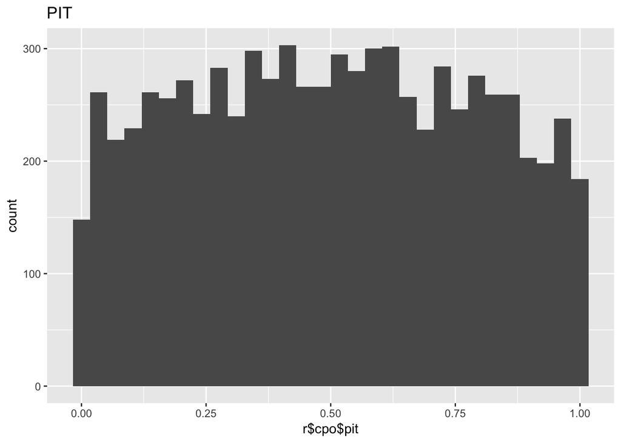

```r
d$PIT
```

## 2.2. (2.1) + predictors

Here we add the climate and time predictors to the null model. This improves model fit.

```r
formula <- YIELD ~ 1 + f(ID, model = "iid") + f(STATE, model = "iid") + GDD + TP + SDD + PERC_IRR + factor(YEAR)
o2 <- inla(formula, data=null, family="gaussian",
           control.predictor = list(compute=T),
           control.compute = list(dic=T, cpo=T))
d <- model_diagnostics(o2, null)
summary(o2) # high precision for ID
```

```
##
## Call:
## c("inla(formula = formula, family = \"gaussian\", data = null, control.compute = list(dic = T, ",  "    cpo = T), control.predictor = list(compute = T))")
##
## Time used:
##  Pre-processing    Running inla Post-processing           Total
##          2.2172         11.9107          0.7795         14.9074
##
## Fixed effects:
##                     mean     sd 0.025quant 0.5quant 0.975quant    mode kld
## (Intercept)      93.1025 6.8038    79.7460  93.1012   106.4541 93.0993   0
## GDD               0.0109 0.0022     0.0066   0.0109     0.0152  0.0109   0
## TP               -0.0126 0.0024    -0.0174  -0.0126    -0.0078 -0.0126   0
## SDD              -0.1070 0.0051    -0.1171  -0.1070    -0.0969 -0.1070   0
## PERC_IRR         68.4807 2.4521    63.6668  68.4805    73.2913 68.4803   0
## factor(YEAR)2002  2.5101 0.9350     0.6743   2.5101     4.3441  2.5101   0
## factor(YEAR)2007 20.0441 1.0381    18.0059  20.0441    22.0805 20.0442   0
## factor(YEAR)2012 12.7915 1.0154    10.7977  12.7915    14.7834 12.7917   0
##
## Random effects:
## Name   Model
##  ID   IID model
## STATE   IID model
##
## Model hyperparameters:
##                                              mean       sd 0.025quant
## Precision for the Gaussian observations 1.400e-03 0.00e+00     0.0014
## Precision for ID                        1.925e+04 2.08e+04  1523.6358
## Precision for STATE                     2.000e-03 3.00e-04     0.0014
##                                          0.5quant 0.975quant      mode
## Precision for the Gaussian observations 1.400e-03  1.400e-03    0.0014
## Precision for ID                        1.304e+04  7.441e+04 4210.6329
## Precision for STATE                     2.000e-03  2.600e-03    0.0020
##
## Expected number of effective parameters(std dev): 47.05(0.1025)
## Number of equivalent replicates : 162.10
##
## Deviance Information Criterion (DIC) ...............: 72292.71
## Deviance Information Criterion (DIC, saturated) ....: 8153.46
## Effective number of parameters .....................: 38.70
##
## Marginal log-Likelihood:  -36305.36
## CPO and PIT are computed
##
## Posterior marginals for linear predictor and fitted values computed
```

```r
# year factor explains a lot of the variance, climate predictors have very small effect.
```

```r
d$DIC
```

```
## [1] 72292.71
```

```r
d$R2
```

```
## [1] 0.4475029
```

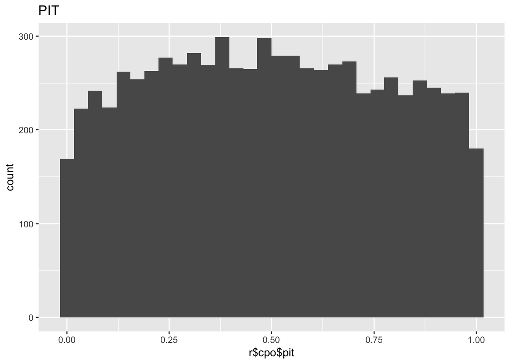

```r
d$PIT
```

## 2.3. Non-linear covariates

Now we add nonlinear effects to the climate predictors since this is well-established in the literature. We start with the recommended values of $u$ and $\alpha$ on the $\theta$ prior. For Gaussian models, the recommended value of $u$ is the empirical standard deviation of the data and $\alpha$ is 0.01 (as described [here](https://inla.r-inla-download.org/r-inla.org/doc/latent/rw1.pdf)). Note that increasing $u$ gives a weaker prior while decreasing $u$ gives a stronger prior.

I also tested fit with a nonlinear irrigation term, but fit was worse, so stuck with a simple linear predictor.

```r
u <- sd(null$YIELD)  # for one year, varies only a tiny bit

formula <- YIELD ~ 1 + f(ID, model = "iid") +
  f(STATE, model = "iid") +
  f(GDD, model = "rw1", scale.model = T, hyper = list(theta = list(prior = "pc.prec",
                                                                   param = c(u, 0.01)))) +
  f(SDD, model = "rw1", scale.model = T, hyper = list(theta = list(prior = "pc.prec",
                                                                   param = c(u, 0.01)))) +
  f(TP, model = "rw1", scale.model = T, hyper = list(theta = list(prior = "pc.prec",
                                                                   param = c(u, 0.01)))) +
  PERC_IRR +
  factor(YEAR)

o3 <- inla(formula, data=null, family="gaussian",
           control.predictor = list(compute=T),
           control.compute = list(dic=T, cpo=T))
d <- model_diagnostics(o3, null)
summary(o3) # high precision for ID
```

```
##
## Call:
## c("inla(formula = formula, family = \"gaussian\", data = null, control.compute = list(dic = T, ",  "    cpo = T), control.predictor = list(compute = T))")
##
## Time used:
##  Pre-processing    Running inla Post-processing           Total
##          2.5054         48.5757          0.4498         51.5309
##
## Fixed effects:
##                     mean     sd 0.025quant 0.5quant 0.975quant    mode kld
## (Intercept)      82.2027 2.3779    77.5399  82.2002    86.8749 82.1957   0
## PERC_IRR         90.8623 2.4336    86.0835  90.8625    95.6354 90.8631   0
## factor(YEAR)2002  0.1622 1.1311    -2.0581   0.1620     2.3816  0.1617   0
## factor(YEAR)2007 20.8403 1.0570    18.7650  20.8403    22.9139 20.8404   0
## factor(YEAR)2012  8.4715 1.1232     6.2664   8.4714    10.6752  8.4712   0
##
## Random effects:
## Name   Model
##  ID   IID model
## STATE   IID model
## GDD   RW1 model
## SDD   RW1 model
## TP   RW1 model
##
## Model hyperparameters:
##                                              mean        sd 0.025quant
## Precision for the Gaussian observations 1.000e-03 0.000e+00     0.0010
## Precision for ID                        2.260e+04 2.071e+04  1353.9287
## Precision for STATE                     1.629e+04 1.595e+04   990.1883
## Precision for GDD                       9.000e-03 3.300e-03     0.0043
## Precision for SDD                       1.020e-02 3.700e-03     0.0045
## Precision for TP                        9.200e-03 3.100e-03     0.0050
##                                          0.5quant 0.975quant      mode
## Precision for the Gaussian observations 1.000e-03  1.000e-03    0.0010
## Precision for ID                        1.661e+04  7.645e+04 3537.3596
## Precision for STATE                     1.154e+04  5.908e+04 2623.2305
## Precision for GDD                       8.400e-03  1.720e-02    0.0073
## Precision for SDD                       9.700e-03  1.880e-02    0.0087
## Precision for TP                        8.600e-03  1.690e-02    0.0075
##
## Expected number of effective parameters(std dev): 81.95(8.099)
## Number of equivalent replicates : 93.06
##
## Deviance Information Criterion (DIC) ...............: 74367.36
## Deviance Information Criterion (DIC, saturated) ....: 7779.76
## Effective number of parameters .....................: 84.14
##
## Marginal log-Likelihood:  -38225.95
## CPO and PIT are computed
##
## Posterior marginals for linear predictor and fitted values computed
```

```r
d$DIC #72271
```

```
## [1] 74367.36
```

```r
d$R2 #.47
```

```
## [1] 0.2761164
```

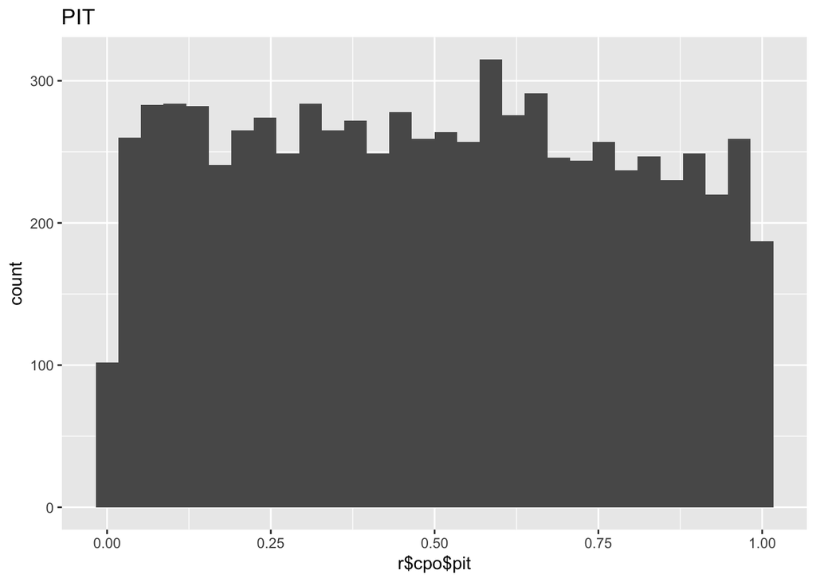

```r
d$PIT # not uniform
```

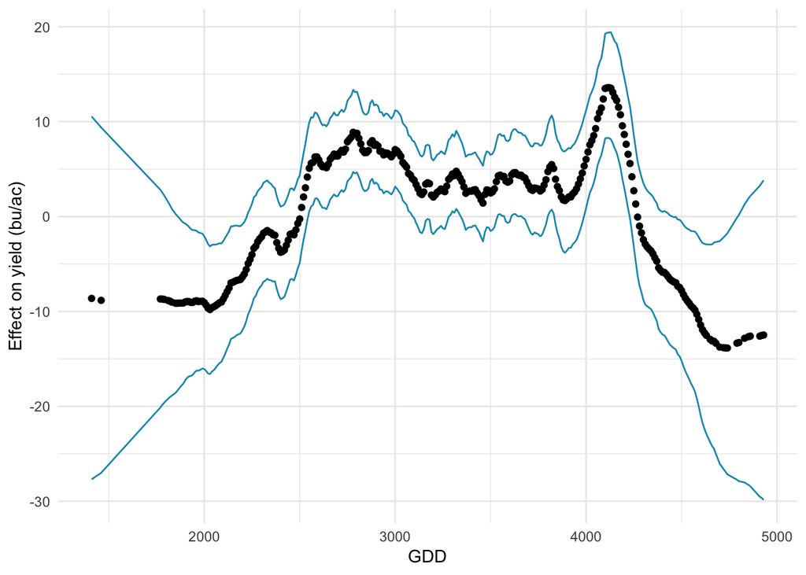

```r
gdd <- nonlinear_effect(o3, "GDD")
sdd <- nonlinear_effect(o3, "SDD")
tp <- nonlinear_effect(o3, "TP")
gdd
```

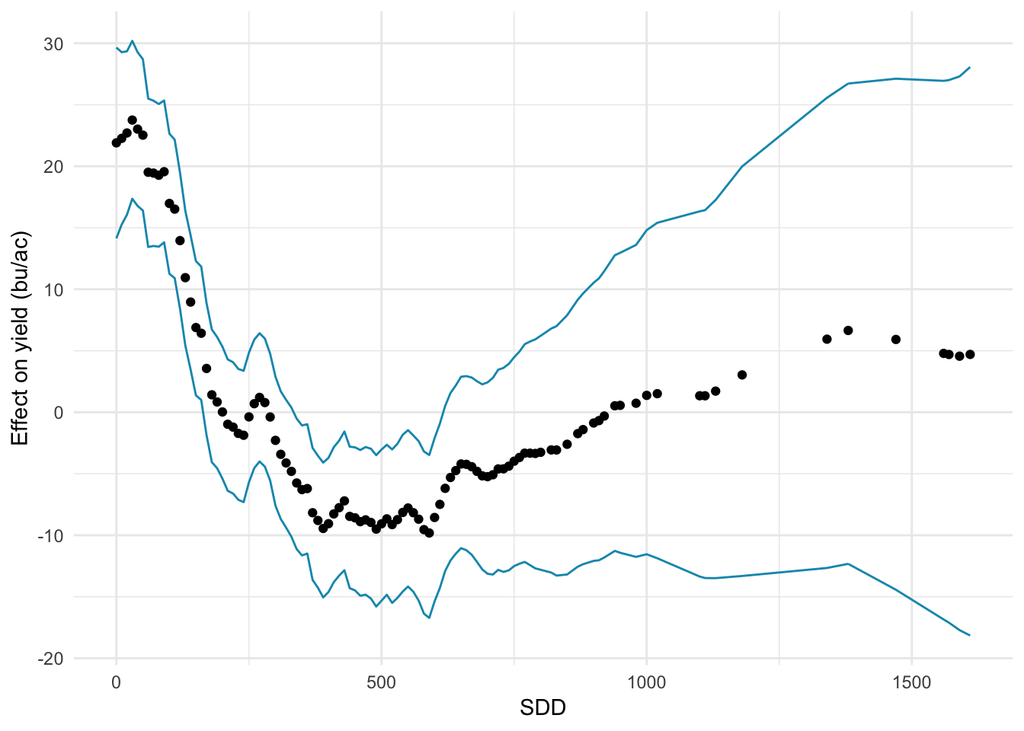

```r
sdd
```

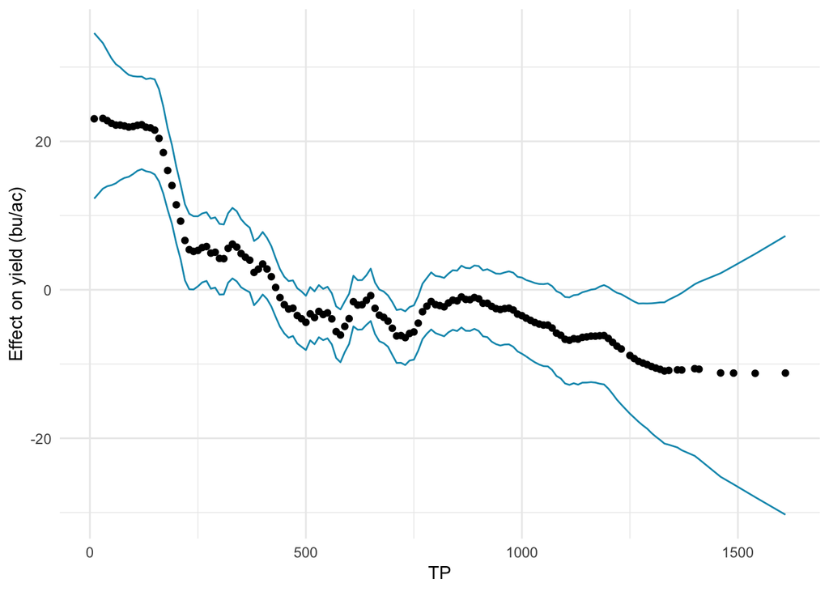

```r
tp
```